# Geçerleme Yaklaşımı

(İktisatçılar İçin) Makine Öğrenmesi (TEK-ES-2021)

Prof. Dr. Hüseyin Taştan

Yıldız Teknik Üniversitesi

Haziran 2021

# 1 Geçerleme Kümesi Yaklaşımı

`auto` veri kümesinden hareketle aşağıdaki modeli tahmin etmek istiyoruz:
$$mpg = \beta_0 + \beta_1 horsepower + \epsilon$$

Eğitim veri kümesini rassal olarak belirliyoruz:

```r
library(ISLR)
# rassal sayı üretecinin başlangıç değeri:
set.seed(1)
# eğitim verileri (gözlem numaraları)
# sample() ile n=392 içinden yerine koymadan 196 sayı çekiyoruz:
train <- sample(392, 196)
```

```r
# modeli sadece eğitimi verileriyle tahmin et:
lmfit <- lm(mpg ~ horsepower,data = Auto, subset = train)
lmfit
```

```
##
## Call:
## lm(formula = mpg ~ horsepower, data = Auto, subset = train)
##
## Coefficients:
## (Intercept)   horsepower
##     41.2835      -0.1697
```

Modelimizi `lmfit` nesnesine kaydettik. Şimdi sadece test verileriyle kestirimleri oluşturalım:

```r
# eğitim ve test verilerini oluştur
train_auto <- Auto[train,]
test_auto <- Auto[-train,]
# eğitim verilerindeki kestirim
train_predict <- predict(lmfit, train_auto)
# Test veri setinde kestirimleri hesapla
test_predict <- predict(lmfit, test_auto)
# Test kestirim hatasını hesapla
test_error <- test_auto$mpg - test_predict
# Ortalama hata karesi (MSE)
mean(test_error^2)
```

```
## [1] 23.26601
```

```r
#
# sadece tek satırda yapmak istersek:
# mean((Auto$mpg-predict(lmfit,Auto))[-train]^2)
```

Alternatif olarak karesel ve kübik modelleri düşünelim:
$$mpg = \beta_0 + \beta_1 horsepower+ \beta_2 horsepower^2 + \epsilon$$

$$mpg = \beta_0 + \beta_1 horsepower+ \beta_2 horsepower^2 + \beta_3 horsepower^3+ \epsilon$$

Karesel model için MSE:

```r
lm.fit2 <- lm(mpg~poly(horsepower,2), data = Auto, subset=train)
mean((Auto$mpg-predict(lm.fit2,Auto))[-train]^2)
```

```
## [1] 18.71646
```

Kübik model için MSE:

```r
lm.fit3 <- lm(mpg~poly(horsepower,3), data = Auto, subset = train)
mean((Auto$mpg-predict(lm.fit3,Auto))[-train]^2)
```

```
## [1] 18.79401
```

Bu sonuçlara göre en düşük test kestirim hatasını veren model karesel modeldir. Acaba sonuçlar geçerleme kümesine ne kadar duyarlı?

Yeni bir geçerleme veri kümesi oluşturup test MSE hesaplayalım:

```r
set.seed(2)
train <- sample(392, 196)
lm.fit <- lm(mpg ~ horsepower, data = Auto, subset = train)
mean((Auto$mpg-predict(lm.fit,Auto))[-train]^2)
```

```
## [1] 25.72651
```

Karesel model:

```r
lm.fit2 <- lm(mpg ~ poly(horsepower,2), data = Auto, subset = train)
mean((Auto$mpg-predict(lm.fit2,Auto))[-train]^2)
```

```
## [1] 20.43036
```

Kübik model:

```r
lm.fit3 <- lm(mpg ~ poly(horsepower,3), data = Auto, subset = train)
mean((Auto$mpg-predict(lm.fit3,Auto))[-train]^2)
```

```
## [1] 20.38533
```

# 2 Biri-Hariç Çapraz Geçerleme (LOOCV)

Biri-hariç çapraz geçerlemede (LOOCV - Leave-one-out Cross Validation) modeli bir gözlemi dışarıda bırakarak tahmin ediyoruz. Dışarıda bırakılan gözlemi kestirim yapmak için kullanıyoruz. Bunun için `boot` paketindeki `cv.glm()` fonksiyonunu `glm()` ile birlikte kullanabiliriz.

`glm()` fonksiyonu `lm()`’e benzer:

```r
# modeli glm ile tahmin et:
glm.fit <- glm(mpg ~ horsepower, data = Auto)
coef(glm.fit)
```

```
## (Intercept)  horsepower
##  39.9358610  -0.1578447
```

```r
# lm ile tahmin:
lm.fit <- lm(mpg ~ horsepower, data = Auto)
coef(lm.fit)
```

```
## (Intercept)  horsepower
##  39.9358610  -0.1578447
```

`cv.glm()` fonksiyonunun kullanımı:

```r
library(boot)
glm.fit <- glm(mpg ~ horsepower, data = Auto)
cv.err <- cv.glm(Auto, glm.fit)
cv.err$delta
```

```
## [1] 24.23151 24.23114
```

`cv.err$delta` çapraz geçerleme ortalama hatasını vermektedir (ilk değer denklem (5.1), ikinci değer ise düzeltilmiş kestirim hatasıdır, burada LOOCV kullanıldığı için her iki değer birbirine çok yakındır). `cv.glm()` default olarak LOOCV uygular. K-katlı çapraz geçerleme için de kullanılabilir.

LOOCV yaklaşımını biraz daha karmaşık modellere uygulayalım ve sonuçları karşılaştıralım. Beşinci dereceye kadar polinom modeller tahmin edeceğiz. Bunu bir döngü içinde yapmak daha pratiktir:

```r
# 5 elemanlı sıfır vektörü; döngü içinde güncellenecek
cv.error <- rep(0,5)
#
for (i in 1:5){
  glm.fit <- glm(mpg ~ poly(horsepower,i), data = Auto)
  cv.error[i] <- cv.glm(Auto, glm.fit)$delta[1]
}
cv.error
```

```
## [1] 24.23151 19.24821 19.33498 19.42443 19.03321
```

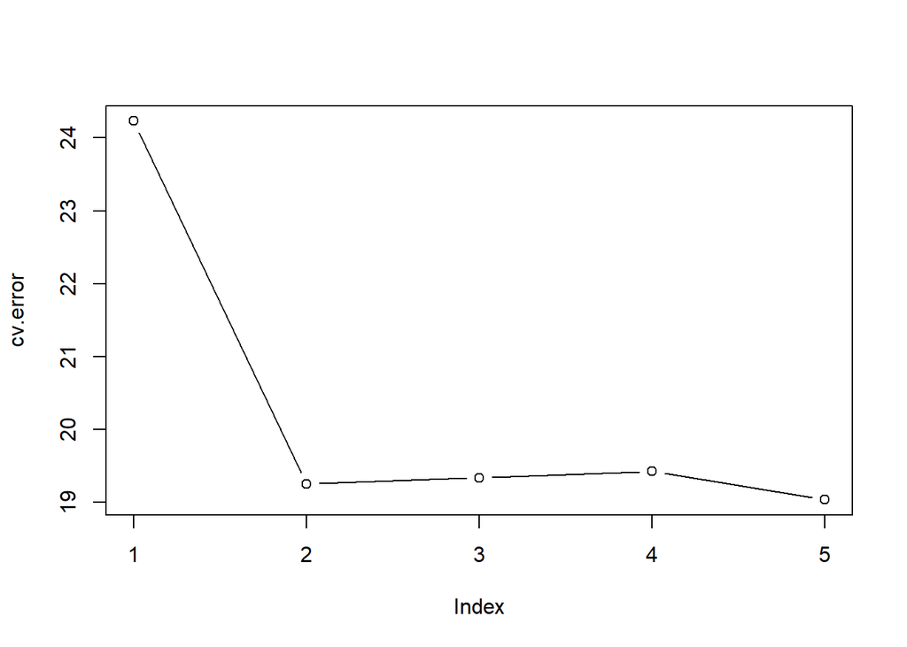

```r
plot(cv.error, type = "b")
```

# 3 $k$-katlı Çapraz Geçerleme

Bunun için `cv.glm()` fonksiyonunu kullanabiliriz. Örneğin, $k=10$ için doğrusal modelde çapraz geçerleme test hatası:

```r
set.seed(12345)
glm.fit <- glm(mpg ~ horsepower, data = Auto)
cv_lin_error_10 <- cv.glm(Auto, glm.fit, K=10)$delta[1]
cv_lin_error_10
```

```
## [1] 24.31806
```

5. dereceye kadar polinom değerler için 10-katlı çapraz geçerleme test hata tahminleri:

```r
# ISLR aynı sonuçlar için seed değeri:
set.seed(17)
cv.error.10 <- rep(0,5)
for (i in 1:5){
  glm.fit <- glm(mpg ~ poly(horsepower,i), data = Auto)
  cv.error.10[i] <- cv.glm(Auto, glm.fit, K=10)$delta[1]
}
cv.error.10
```

```
## [1] 24.27207 19.26909 19.34805 19.29496 19.03198
```

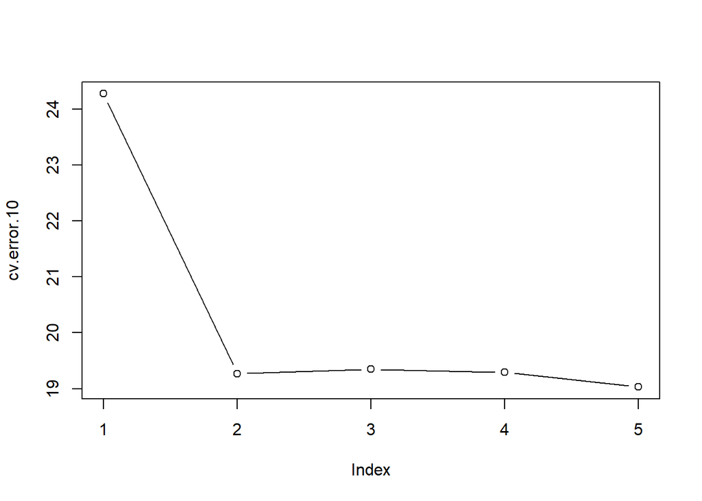

```r
plot(cv.error.10, type = "b")
```

# 4 Bootstrap

Bootstrap tekniğinin uygulanması oldukça basittir. Bunun için ilgilendiğimiz istatistik ya da tahminciyi hesaplayan bir fonksiyona ve elimizdeki verilerden *yerine koymalı örnekleme* yapabilen ayrı bir fonksiyona ihtiyacımız vardır.

Örnek olarak yöntemi öneren Efron, B. ve R. Tibshrani’nin orijinal makalelerinde kullandıkları verileri ele alalım (bkz. “Bootstrap Methods for Standard Errors, Confidence Intervals and Other measures of Statisical Accuracy.” Statistical Science, 1(1986): 54-77).

Bu veri setinde ABD’deki 15 hukuk fakültesinin 1973 yılı ortalama LSAT puanları ile GPA değerleri yer almaktadır:

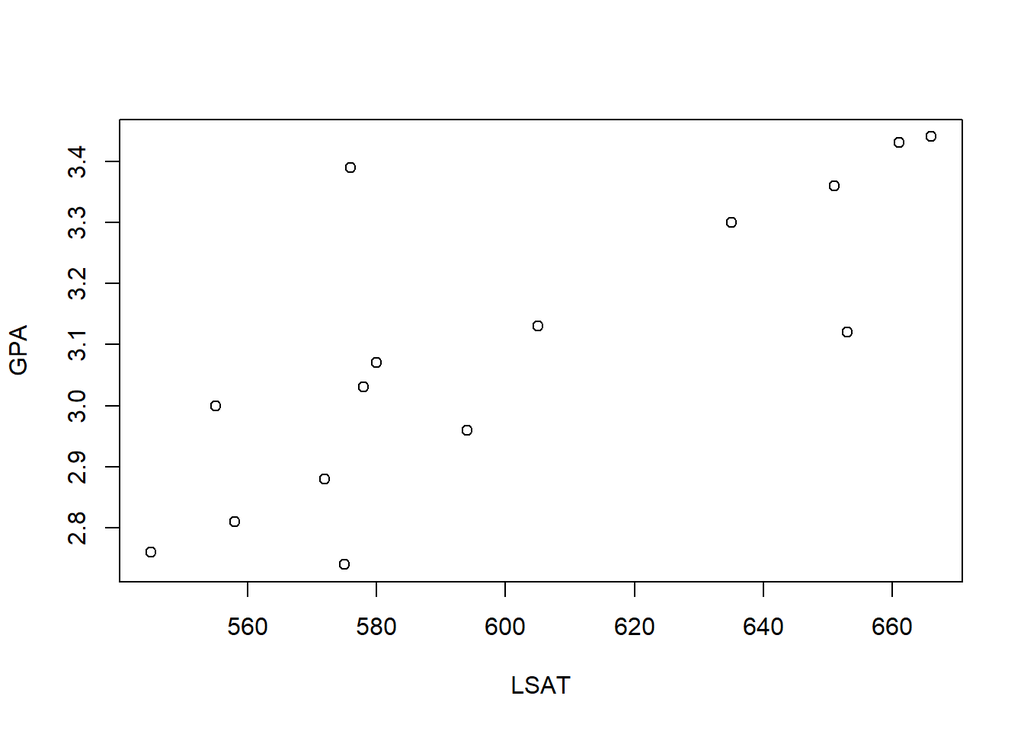

```r
LSAT <- c(576, 635, 558, 578, 666, 580, 555, 661, 651, 605, 653, 575, 545, 572, 594)
GPA <- c(3.39, 3.30, 2.81, 3.03, 3.44, 3.07, 3.00, 3.43, 3.36, 3.13,
        3.12, 2.74, 2.76, 2.88, 2.96)
data <- data.frame(LSAT,GPA)
plot(LSAT,GPA)
```

Amacımız korelasyon katsayısının standart hatasını “bootstrap” tekniği ile tahmin etmek. Örneklem korelasyon katsayısı:

```r
cor(LSAT, GPA)
```

```
## [1] 0.7763745
```

Bootstrap standart hatasını bulmak için verilerden rassal olarak ve yerine koyarak $n$ boyutlu örneklemler çekip her örneklem için korelasyon katsayısını hesaplayacağız ve kaydedeceğiz. Amacımız korelasyon katsayısının örnekleme dağılımını tahmin etmektir. Bu amaçla `sample(n, n, replace=TRUE)` komutunu $B=1000$ yinelemeli olarak kullanabiliriz:

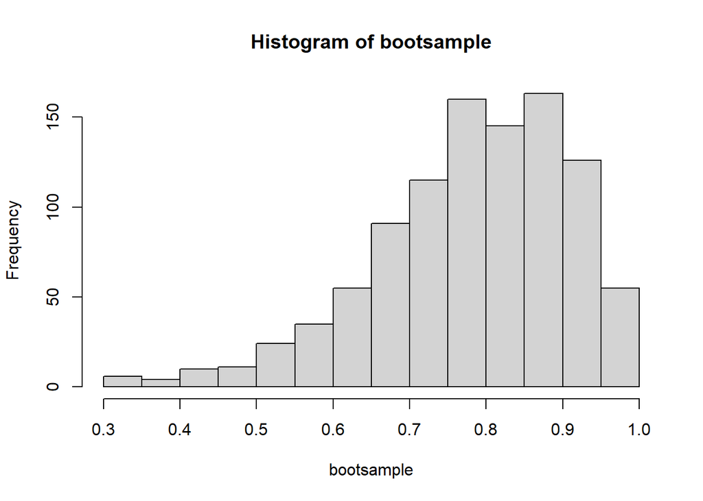

```r
set.seed(111)
B <- 1000
bootsample <- rep(0,B)
for (i in 1:B){
  index <- sample(15,15,replace = TRUE)
  bootsample[i] <- cor(LSAT[index], GPA[index])
}
hist(bootsample)
```

```r
sqrt(var(bootsample))
```

```
## [1] 0.127539
```

```r
summary(bootsample)
```

```
##    Min. 1st Qu.  Median    Mean 3rd Qu.    Max.
##  0.3128  0.7049  0.7955  0.7803  0.8772  0.9972
```

Bootstrap standart hatası 0.1275 olarak tahmin edilmiştir (yukarıda referansını verdiğimiz makaledeki sonuçla pratik olarak aynıdır). Bootstrap ortalamasının, 0.7803, örneklem korelasyon katsayısı, 0.776, ile örtüştüğüne dikkat ediniz.

`R` `boot()` fonksiyonu yukarıdaki hesaplamayı otomatikleştirir. Ancak bunun için öncelikle bir fonksiyon yazmalıyız. Aşağıdaki örnekte `corboot()` fonksiyonu örneklem korelasyon katsayısını, gözlem numaralarını içeren `index` kümesini kullanarak hesaplar ve çıktı olarak verir. Daha fazla detay için `boot()` yardım dosyasına bakılabilir.

```r
# örneklem istatistiğini hesaplayan jenerik fonksiyon
corboot <- function(data, index){
  X <- data[index,1]
  Y <- data[index,2]
  return(cor(X,Y))
}
# boot fonksiyonunun kullanımı
library(boot)
set.seed(111)
boot(data = data, statistic = corboot, R=1000)
```

```
##
## ORDINARY NONPARAMETRIC BOOTSTRAP
##
##
## Call:
## boot(data = data, statistic = corboot, R = 1000)
##
##
## Bootstrap Statistics :
##      original       bias    std. error
## t1* 0.7763745 0.0009153723   0.1311586
```

Bootstrap standart hatası 0.131 olarak tahmin edilmiştir.

## 4.1 Regresyon Modelinde Bootstrap Standart Hataları

Bootstrap tekniği bir makine öğrenmesi yönteminin katsayı tahminlerindeki değişkenliğin ölçülmesinde kullanılabilir. Örneğin doğrusal regresyon modelinde katsayı tahminlerinin standart hataları bootstrap yaklaşımı ile hesaplanabilir. Kesit veri setinin ilgili anakütleden bağımsız ve türdeş (iid) örnekleme ile çekildiği varsayımını yapıyoruz. Bu yaklaşım ölçümler arasında bağımlılığın olduğu zaman serilerine burada ele aldığımız yalın haliyle uygulanamaz. Zaman serileri için geliştirilmiş daha karmaşık bootstrap yöntemleri vardır (burada değinmeyeceğiz).

Sıradan en küçük kareler (OLS) tahmincilerinin standart hata formülleri incelenirse bu formüllerin bazı varsayımlar altında geçerli olduğu kolayca görülebilir. Bunlardan en önemlisi hata teriminin varyansının, $\sigma^2$, sabit olmasıdır. Değişen varyans (heteroskedasticity) durumunda veya modelde dikkate alınmamış doğrusal olmayan ilişkiler varsa bu standart hata formülleri geçerli olmaz. Bootstrap yöntemi ise bu varsayımlara dayanmaz. Yani değişen varyans altında da geçerlidir.

Bootstrap standart hatalarını hesaplamak için önce `boot.fn()` isimli bir fonksiyon yazalım. Bu fonksiyon iki girdiye sahiptir, `data` ve `index`. İkinci girdi gözlemlerin numaralarını içermektedir. Böylece farklı bootstrap örneklemleri için OLS tahmini yinelenebilir. Kolaylık amacıyla sadece `mpg` modeli için geçerli olacak şekilde yazılmıştır:

```r
boot.fn <- function(data, index)
  return(coef(lm(mpg ~ horsepower, data = data, subset = index)))
# örnek: tüm gözlemleri kullan
boot.fn(Auto,1:392)
```

```
## (Intercept)  horsepower
##  39.9358610  -0.1578447
```

Yerine koymalı bootstrap örnekleri:

```r
set.seed(1)
# 1. bootstrap
boot.fn(Auto, sample(392, 392, replace=T))
```

```
## (Intercept)  horsepower
##  40.3404517  -0.1634868
```

```r
# 2. bootstrap
boot.fn(Auto, sample(392, 392, replace=T))
```

```
## (Intercept)  horsepower
##  40.1186906  -0.1577063
```

Şimdi `boot()` fonksiyonunu çağırabiliriz:

```r
boot(Auto, boot.fn, 1000)
```

```
##
## ORDINARY NONPARAMETRIC BOOTSTRAP
##
##
## Call:
## boot(data = Auto, statistic = boot.fn, R = 1000)
##
##
## Bootstrap Statistics :
##       original        bias    std. error
## t1* 39.9358610  0.0544513229 0.841289790
## t2* -0.1578447 -0.0006170901 0.007343073
```

```r
summary(lm(mpg ~ horsepower, data=Auto))$coef
```

```
##               Estimate  Std. Error   t value      Pr(>|t|)
## (Intercept) 39.9358610 0.717498656  55.65984 1.220362e-187
## horsepower  -0.1578447 0.006445501 -24.48914  7.031989e-81
```

OLS standart hataları daha düşüktür. Ancak doğrusal modelin iyi bir uyum sergilemediği düşünülürse bootstrap standart hatalarının daha sapmasız bir standart hata tahmini verdiğini söyleyebiliriz.

`mpg` için karesel model daha başarılı bir uyum göstermişti. Bu model için bootstrap standart hataları hesaplayalım:

```r
boot.fn2 <- function(data, index)
  coefficients(lm(mpg ~ horsepower + I(horsepower^2), data = data, subset=index))
set.seed(1)
boot(Auto, boot.fn2, 1000)
```

```
##
## ORDINARY NONPARAMETRIC BOOTSTRAP
##
##
## Call:
## boot(data = Auto, statistic = boot.fn2, R = 1000)
##
##
## Bootstrap Statistics :
##         original        bias     std. error
## t1* 56.900099702  3.511640e-02 2.0300222526
## t2* -0.466189630 -7.080834e-04 0.0324241984
## t3*  0.001230536  2.840324e-06 0.0001172164
```

OLS sonuçları ile kıyaslayınız:

```r
summary(lm(mpg~horsepower+I(horsepower^2),data=Auto))$coef
```

```
##                     Estimate   Std. Error   t value      Pr(>|t|)
## (Intercept)     56.900099702 1.8004268063  31.60367 1.740911e-109
## horsepower      -0.466189630 0.0311246171 -14.97816  2.289429e-40
## I(horsepower^2)  0.001230536 0.0001220759  10.08009  2.196340e-21
```

# 5 Tidymodels Kütüphaneleri

[Tidymodels](https://www.tidymodels.org/) makine öğrenmesi modellerinin kolayca eğitilmesi ve değerlendirilmesi için oluşturulmuş paketler topluluğudur. Tidyverse yaklaşımını takip eden bu paketler şunlardır:

- `{rsample}`: yeniden örnekleme
- `{recipes}`: kestirim değişkenlerinin belirlenmesi
- `{parsnip}`: modelin eğitilmesi
- `{tune}`, `{dials}`: modelin hiperparametrelerinin belirlenmesi
- `{yardstick}`: modelin performansının değerlendirilmesi

[figure not shown]

Giriş için bkz. https://www.tidymodels.org/start/

```r
# first install tidymodels
# needs to be done once
# install.packages("tidymodels")
```

Örnek olarak `Auto` veri setini kullanarak bir regresyon modeli tahmin edelim.

Önce verileri eğitim ve test olmak üzere iki kısma ayıralım. Bunun için `{rsample}` paketindeki `initial_split()` fonksiyonunu kullanabiliriz.

Çıktı değişkenimiz `mpg` kestirim değişkenimiz ise `horsepower`. Verilerin rassal seçilmiş yüzde 75’ini eğitim, %25’ini de test verisi olarak kullanacağız.

```r
library(tidymodels)
library(ISLR)
set.seed(1)
auto_split <- initial_split(Auto,
                           prop = 0.75,
                           strata = mpg)
```

Yukarıda `strata` opsiyonu ile bağımlı değişkenin hem eğitim hem de test verilerinde aşağı yukarı benzer bir dağılıma sahip olması sağlanabilir.

Eğitim verileri:

```r
auto_train <- auto_split %>% training()
head(auto_train)
```

```
##    mpg cylinders displacement horsepower weight acceleration year origin
## 2   15         8          350        165   3693         11.5   70      1
## 4   16         8          304        150   3433         12.0   70      1
## 8   14         8          440        215   4312          8.5   70      1
## 9   14         8          455        225   4425         10.0   70      1
## 13  15         8          400        150   3761          9.5   70      1
## 14  14         8          455        225   3086         10.0   70      1
##                       name
## 2        buick skylark 320
## 4            amc rebel sst
## 8        plymouth fury iii
## 9         pontiac catalina
## 13   chevrolet monte carlo
## 14 buick estate wagon (sw)
```

Test verileri

```r
auto_test <- auto_split %>% testing()
head(auto_test)
```

```
##    mpg cylinders displacement horsepower weight acceleration year origin
## 5   17         8          302        140   3449         10.5   70      1
## 6   15         8          429        198   4341         10.0   70      1
## 7   14         8          454        220   4354          9.0   70      1
## 10  15         8          390        190   3850          8.5   70      1
## 11  15         8          383        170   3563         10.0   70      1
## 12  14         8          340        160   3609          8.0   70      1
##                   name
## 5          ford torino
## 6     ford galaxie 500
## 7     chevrolet impala
## 10  amc ambassador dpl
## 11 dodge challenger se
## 12  plymouth 'cuda 340
```

`auto_test` verileri en sonda sadece model değerlendirmesinde kullanılacak.

`mpg`’nin `horsepower` üzerine regresyonunda `{parsnip}` paketi kullanılabilir. Adımlar:

1. Model türünü belirle: `parsnip::linear_reg()`.
2. Model tahmininde kullanılacak fonksiyonu belirle (engine, `lm()` fonksiyonu): `parsnip::set_engine('lm')`.
3. Gözetimli öğrenme türünü belirle (sınıflandırma ya da regresyon) `parsnip::set_mode('regression')`.

Tahmin nesnesini oluştur: `lm_model`

```r
lm_model <- linear_reg() %>%
  set_engine('lm') %>%
  set_mode('regression')
```

```r
lm_model
```

```
## Linear Regression Model Specification (regression)
##
## Computational engine: lm
```

`parsnip::fit()` fonksiyonu ile modeli eğit:

```r
auto_fit <- lm_model %>%
  fit(mpg ~ horsepower, data = auto_train)
```

Tablo haline getir:

```r
tidy(auto_fit)
```

```
## # A tibble: 2 x 5
##   term        estimate std.error statistic   p.value
##   <chr>          <dbl>     <dbl>     <dbl>     <dbl>
## 1 (Intercept)   39.9     0.844        47.2 3.38e-138
## 2 horsepower    -0.157   0.00759     -20.7 3.18e- 59
```

Test verilerini kullanarak kestirim değerlerini oluştur:

```r
auto_preds <- auto_fit %>%
  predict(new_data = auto_test)
```

`auto_preds` nesnesinin elemanları:

```r
head(auto_preds)
```

```
## # A tibble: 6 x 1
##   .pred
##   <dbl>
## 1 17.8
## 2  8.71
## 3  5.25
## 4  9.97
## 5 13.1
## 6 14.7
```

`.pred` sütünunda yer alan değerler test verileriyle oluşturulmuştur.

Test setinde yer alan `mpg` ve `horsepower` verileriyle birleştir:

```r
auto_test_results <- auto_test %>%
  select(mpg, horsepower) %>%
  bind_cols(auto_preds)
```

Veri setine göz at:

```r
head(auto_test_results)
```

```
##    mpg horsepower     .pred
## 5   17        140 17.841972
## 6   15        198  8.710310
## 7   14        220  5.246575
## 10  15        190  9.969849
## 11  15        170 13.118698
## 12  14        160 14.693123
```

`{yardstick}` ile değerlendirme metriklerini hesapla. Burada `rmse()` ölçütünü kullanacağız:

```r
auto_test_results %>%
  rmse(truth = mpg, estimate = .pred)
```

```
## # A tibble: 1 x 3
##   .metric .estimator .estimate
##   <chr>   <chr>          <dbl>
## 1 rmse    standard        4.66
```

Bunu hesaplamak için gerçek değerlere ve kestirim değerlerine ihtiyaç duyuyoruz.

Gerçek ile kestirim arasındaki R-squared de ölçüt olabilir:

```r
auto_test_results %>%
  rsq(truth = mpg, estimate = .pred)
```

```
## # A tibble: 1 x 3
##   .metric .estimator .estimate
##   <chr>   <chr>          <dbl>
## 1 rsq     standard       0.632
```

Görselleştirelim:

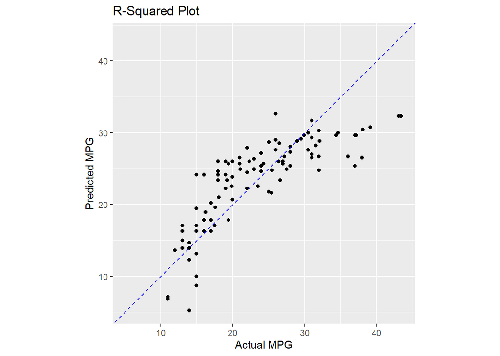

```r
ggplot(auto_test_results, aes(x = mpg, y = .pred)) +
  geom_point() +
  geom_abline(color = 'blue', linetype = 2) +
  coord_obs_pred() +
  labs(title = 'R-Squared Plot',
       y = 'Predicted MPG',
       x = 'Actual MPG')
```

Başarılı bir kestirim modeli için noktaların 45 derece doğrusu üzerinde dizilmesini bekleriz. Bu örnekte böyle olmadığını görüyoruz.

Modele karesel terimler ekleyelim:

```r
auto_fit2 <- lm_model %>%
  fit(mpg ~ horsepower + I(horsepower^2), data = auto_train)
```

```r
tidy(auto_fit2)
```

```
## # A tibble: 3 x 5
##   term            estimate std.error statistic  p.value
##   <chr>              <dbl>     <dbl>     <dbl>    <dbl>
## 1 (Intercept)     57.1      2.14         26.7  4.04e-80
## 2 horsepower      -0.470    0.0369      -12.7  7.78e-30
## 3 I(horsepower^2)  0.00124  0.000144      8.62 4.37e-16
```

Test verisiyle kestirimler:

```r
auto_preds2 <- auto_fit2 %>%
  predict(new_data = auto_test)
```

```r
auto_preds2
```

```
## # A tibble: 100 x 1
##    .pred
##    <dbl>
##  1  15.7
##  2  12.8
##  3  13.9
##  4  12.7
##  5  13.1
##  6  13.7
##  7  23.2
##  8  26.2
##  9  38.1
## 10  24.9
## # ... with 90 more rows
```

```r
auto_test_results2 <- auto_test %>%
  select(mpg, horsepower) %>%
  bind_cols(auto_preds2)
```

```r
head(auto_test_results2)
```

```
##    mpg horsepower    .pred
## 5   17        140 15.69022
## 6   15        198 12.79238
## 7   14        220 13.87964
## 10  15        190 12.69516
## 11  15        170 13.14781
## 12  14        160 13.74682
```

`{yardstick}` paketiyle metrikleri hesapla:

```r
auto_test_results2 %>%
  rmse(truth = mpg, estimate = .pred)
```

```
## # A tibble: 1 x 3
##   .metric .estimator .estimate
##   <chr>   <chr>          <dbl>
## 1 rmse    standard        4.12
```

Bu model birinci modele göre daha başarılıdır.

```r
auto_test_results2 %>%
  rsq(truth = mpg, estimate = .pred)
```

```
## # A tibble: 1 x 3
##   .metric .estimator .estimate
##   <chr>   <chr>          <dbl>
## 1 rsq     standard       0.712
```

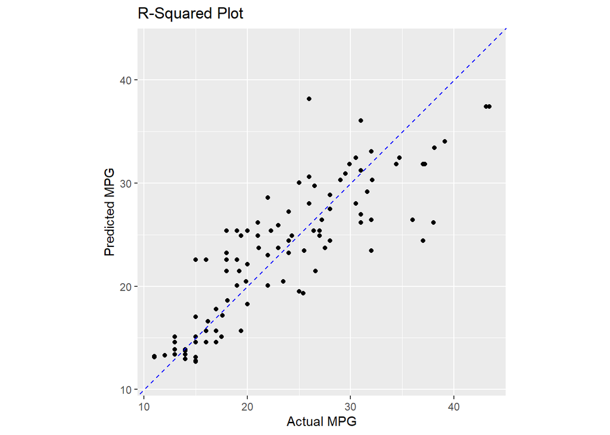

```r
ggplot(auto_test_results2, aes(x = mpg, y = .pred)) +
  geom_point() +
  geom_abline(color = 'blue', linetype = 2) +
  coord_obs_pred() +
  labs(title = 'R-Squared Plot',
       y = 'Predicted MPG',
       x = 'Actual MPG')
```

R-kare daha yüksek çıktı.

Model seçimi tamamlandıktan sonra `{tune}` paketindeki `last_fit()` fonksiyonu ile

1. eğitim-test ayrımını yapabilir
2. eğitim verisiyle modeli tahmin edebilir
3. kestirimleri oluşturup değerlendirme ölçütlerini hesaplayabilir
4. ve bunları bir nesne içinde saklayabiliriz.

```r
lm_last_fit <- lm_model %>%
  last_fit(mpg ~ horsepower + I(horsepower^2),
           split = auto_split)
```

`tune::collect_metrics()` fonksiyonu model değerlendirme ölçütlerini hesaplar:

```r
lm_last_fit %>%
  collect_metrics()
```

```
## # A tibble: 2 x 4
##   .metric .estimator .estimate .config
##   <chr>   <chr>          <dbl> <chr>
## 1 rmse    standard       4.12  Preprocessor1_Model1
## 2 rsq     standard       0.712 Preprocessor1_Model1
```

`tune::collect_predictions()` gerçek ve kestirim değerlerini içeren bir tibble oluşturur:

```r
lm_last_fit %>%
  collect_predictions()
```

```
## # A tibble: 100 x 5
##    id               .pred  .row   mpg .config
##    <chr>            <dbl> <int> <dbl> <chr>
##  1 train/test split  15.7     5    17 Preprocessor1_Model1
##  2 train/test split  12.8     6    15 Preprocessor1_Model1
##  3 train/test split  13.9     7    14 Preprocessor1_Model1
##  4 train/test split  12.7    10    15 Preprocessor1_Model1
##  5 train/test split  13.1    11    15 Preprocessor1_Model1
##  6 train/test split  13.7    12    14 Preprocessor1_Model1
##  7 train/test split  23.2    17    18 Preprocessor1_Model1
##  8 train/test split  26.2    18    21 Preprocessor1_Model1
##  9 train/test split  38.1    20    26 Preprocessor1_Model1
## 10 train/test split  24.9    25    21 Preprocessor1_Model1
## # ... with 90 more rows
```

Tidymodels ile k-katlı çapraz geçerleme yapılabilir.

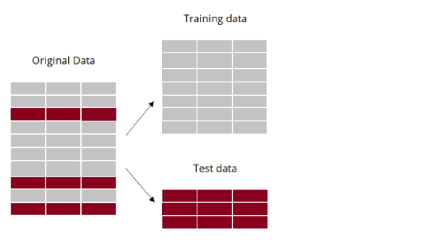

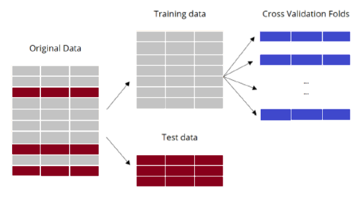

k=5 için CV katlarının oluşturulması:

```r
set.seed(12)
folds <- vfold_cv(auto_train, v = 5)
folds
```

```
## #  5-fold cross-validation
## # A tibble: 5 x 2
##   splits           id
##   <list>           <chr>
## 1 <split [233/59]> Fold1
## 2 <split [233/59]> Fold2
## 3 <split [234/58]> Fold3
## 4 <split [234/58]> Fold4
## 5 <split [234/58]> Fold5
```

Bir akış (workflow) oluşturup tüm katlar için tahminleri yapabiliriz:

```r
auto_wf <- workflow() %>%
  add_model(lm_model) %>%
  add_formula(mpg ~ horsepower + I(horsepower^2))
auto_wf
```

```
## == Workflow ====================================================================
## Preprocessor: Formula
## Model: linear_reg()
##
## -- Preprocessor ----------------------------------------------------------------
## mpg ~ horsepower + I(horsepower^2)
##
## -- Model -----------------------------------------------------------------------
## Linear Regression Model Specification (regression)
##
## Computational engine: lm
```

```r
auto_fit_rs <- auto_wf %>%
  fit_resamples(folds)
auto_fit_rs
```

```
## # Resampling results
## # 5-fold cross-validation
## # A tibble: 5 x 4
##   splits           id    .metrics         .notes
##   <list>           <chr> <list>           <list>
## 1 <split [233/59]> Fold1 <tibble [2 x 4]> <tibble [0 x 1]>
## 2 <split [233/59]> Fold2 <tibble [2 x 4]> <tibble [0 x 1]>
## 3 <split [234/58]> Fold3 <tibble [2 x 4]> <tibble [0 x 1]>
## 4 <split [234/58]> Fold4 <tibble [2 x 4]> <tibble [0 x 1]>
## 5 <split [234/58]> Fold5 <tibble [2 x 4]> <tibble [0 x 1]>
```

```r
collect_metrics(auto_fit_rs)
```

```
## # A tibble: 2 x 6
##   .metric .estimator  mean     n std_err .config
##   <chr>   <chr>      <dbl> <int>   <dbl> <chr>
## 1 rmse    standard   4.46      5  0.225  Preprocessor1_Model1
## 2 rsq     standard   0.689     5  0.0240 Preprocessor1_Model1
```

Yukarıdaki tabloda yer alan metrikler 5 kat için ortalamalardır.